# Title of Lecture

## The Binomial Data Model and Likelihood Function

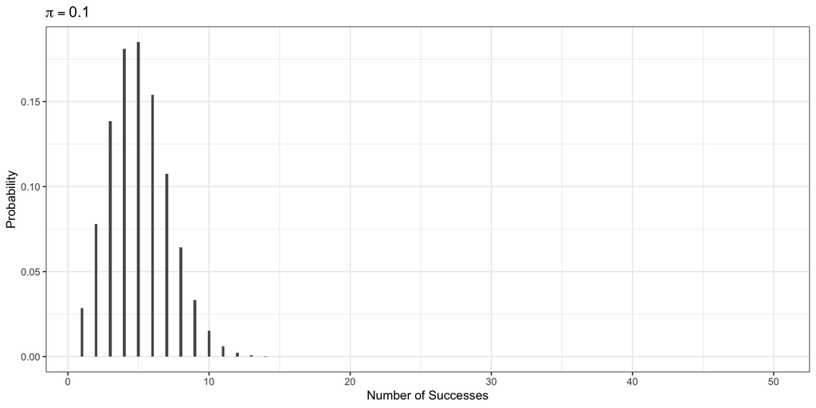

## The Binomial Data Model and Likelihood Function

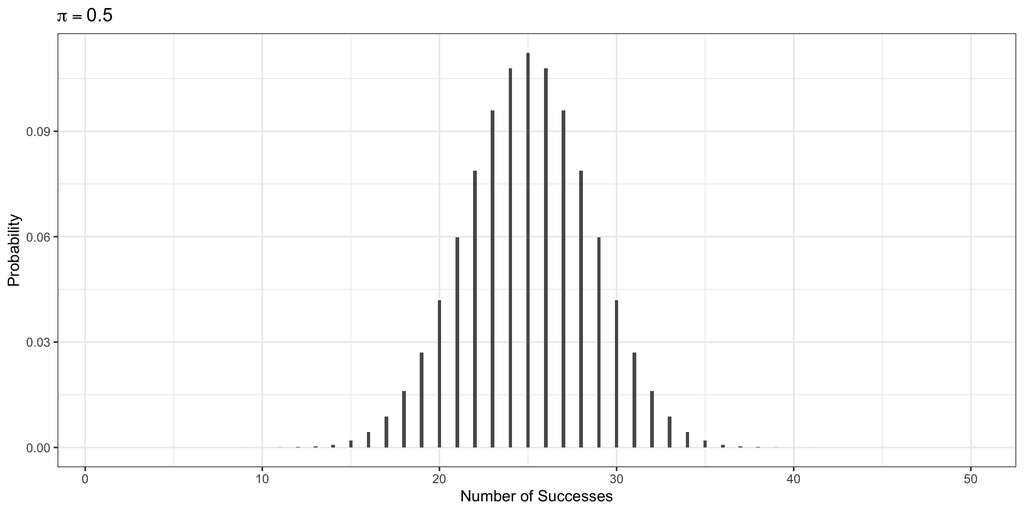

## The Binomial Data Model and Likelihood Function

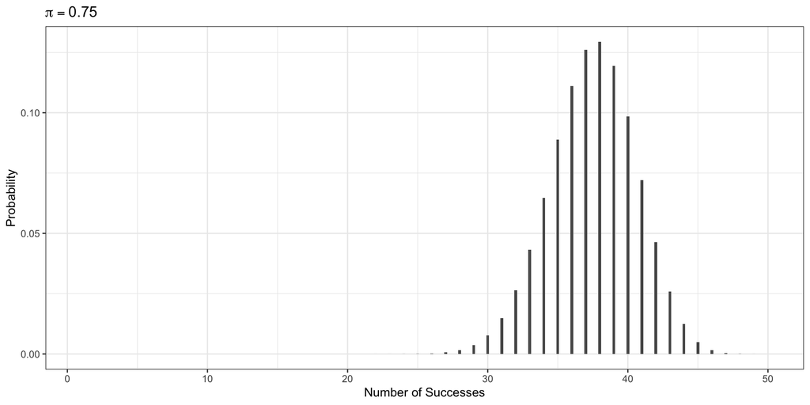

## The Binomial Data Model and Likelihood Function

- It is observed that $Y=30$ of the $n=50$ polled voters support Michelle.
- We now want to find the likelihood function – remember that we treat $Y=30$ as the observed data and $\pi$ as unknown,

$$\begin{align*}
f(y|\pi) &= {50 \choose y} \pi^y (1-\pi)^{50-y} \\
L(\pi|y=30) &= {50 \choose 30} \pi^{30} (1-\pi)^{20}
\end{align*}$$

- This is valid for $\pi \in [0, 1]$.

## The Binomial Data Model and Likelihood Function

- What is the likelihood of 30/50 voters supporting Michelle?

```r
dbinom(30, 50, pi)
```

- You try this for $\pi = \{0.25, 0.50, 0.75\}$.

## The Binomial Data Model and Likelihood Function

- What is the likelihood of 30/50 voters supporting Michelle?

```r
dbinom(30, 50, pi)
```

- You try this for $\pi = \{0.25, 0.50, 0.75\}$.

```r
dbinom(30, 50, 0.25)
dbinom(30, 50, 0.5)
dbinom(30, 50, 0.75)
```

## The Binomial Data Model and Likelihood Function

- What is the likelihood of 30/50 voters supporting Michelle?

```r
dbinom(30, 50, 0.25)
```

```
[1] 1.29633e-07
```

```r
dbinom(30, 50, 0.5)
```

```
[1] 0.04185915
```

```r
dbinom(30, 50, 0.75)
```

```
[1] 0.007654701
```

## The Binomial Data Model and Likelihood Function

- Challenge!
- Create a graph showing what happens to the likelihood for different values of $\pi$.
  - i.e., have $\pi$ on the $x$-axis and likelihood on the $y$-axis.
- To get you started,

```r
graph <- tibble(pi = seq(0, 1, 0.001)) %>%
  mutate(likelihood = dbinom(30, 50, pi))
```

## The Binomial Data Model and Likelihood Function

- Create a graph showing what happens to the likelihood for different values of $\pi$.

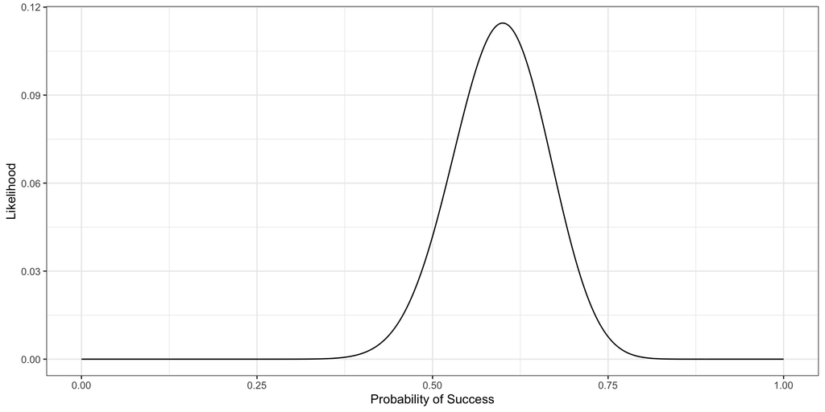

- Where is the maximum?

## The Binomial Data Model and Likelihood Function

- Where is the maximum?

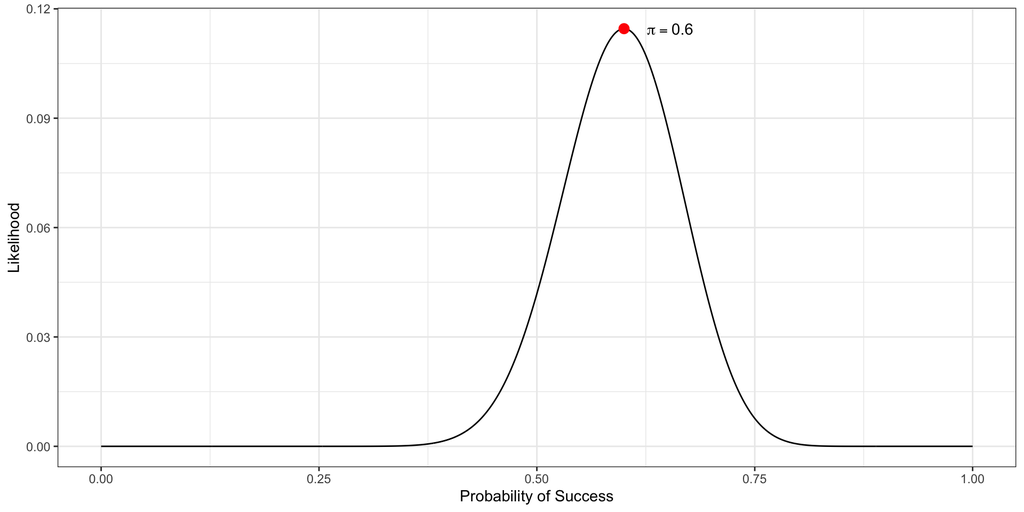

## The Beta Posterior Model

$$\begin{align*}
Y|\pi &\sim \text{Bin}(50, \pi) \\
\pi &\sim \text{Beta}(45, 55)
\end{align*}$$

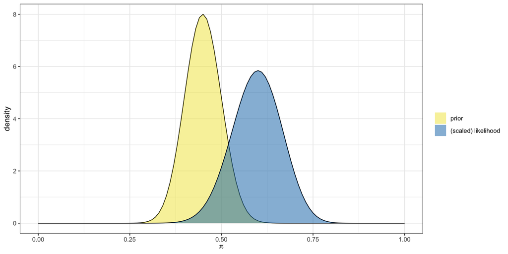

- The prior is a bit more pessimistic about Michelle’s election support than the data obtained from the latest poll.

## The Beta Posterior Model

- Let’s graph the posterior,

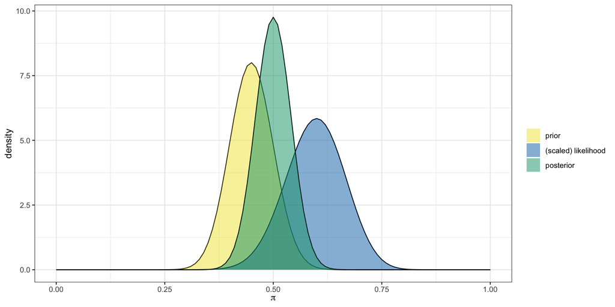

```r
plot_beta_binomial(alpha = 45, beta = 55, y = 30, n = 50) + theme_bw()
```

- We can see that the posterior model of $\pi$ is continuous and $\in [0, 1]$.
- The shape of the posterior appears to also have a Beta($\alpha$, $\beta$) model.
  - The shape parameters ($\alpha$ and $\beta$) have been *updated*.

## The Beta Posterior Model

- If we were to collect more information about Michelle’s support, we would use the current posterior as the new prior, then update our posterior.
  - How do we know what the updated parameters are?

```r
summarize_beta_binomial(alpha = 45, beta = 55, y = 30, n = 50)
```

| model | alpha | beta | mean | mode | var | sd |
| --- | --- | --- | --- | --- | --- | --- |
| prior | 45 | 55 | 0.45 | 0.4489796 | 0.002450495 | 0.04950248 |
| posterior | 75 | 75 | 0.50 | 0.5000000 | 0.001655629 | 0.04068942 |

## The Beta Posterior Model

- We used Michelle’s election support to understand the Beta-Binomial model.
- Let’s now generalize it for any appropriate situation.

$$\begin{align*}
Y|\pi &\sim \text{Bin}(n, \pi) \\
\pi &\sim \text{Beta}(\alpha, \beta) \\
\pi | (Y=y) &\sim \text{Beta}(\alpha+y, \beta+n-y)
\end{align*}$$

- We can see that the posterior distribution reveals the influence of the prior ($\alpha$ and $\beta$) and data ($y$ and $n$).

## The Beta Posterior Model

- Under this updated distribution,

$$\pi | (Y=y) \sim \text{Beta}(\alpha+y, \beta+n-y)$$

## The Beta Posterior Model

- Let’s pause and think about this from a theoretical standpoint.
- The Beta distribution is a *conjugate prior* for the likelihood.
  - **Conjugate prior**: the posterior is from the same model family as the prior.
- Recall the Beta prior, $f(\pi)$,

$$f(\pi) = \frac{\Gamma(\alpha+\beta)}{\Gamma(\alpha)\Gamma(\beta)} \pi^{\alpha-1}(1-\alpha)^{\beta-1}$$

## The Beta Posterior Model

- We can put the prior and likelihood together to create the posterior,

$$\begin{align*}
f(\pi|y) &\propto f(\pi)L(\pi|y) \\
&= \frac{\Gamma(\alpha+\beta)}{\Gamma(\alpha)\Gamma(\beta)} \pi^{\alpha-1}(1-\pi)^{\beta-1} \times {n \choose y} \pi^y (1-\pi)^{n-1} \\
&\propto \pi^{(\alpha+y)-1} (1-\pi)^{(\beta+n-y)-1}
\end{align*}$$

- This is the same structure as the normalized Beta($\alpha+y, \beta+n-y$),

$$f(\pi|y) = \frac{\Gamma(\alpha+\beta+n)}{\Gamma(\alpha+y) \Gamma(\beta+n-y)} \pi^{(\alpha+y)-1} (1-\pi)^{(\beta+n-y)-1}$$

## Example Set Up

- In a 1963 issue of The Journal of Abnormal and Social Psychology, Stanley Milgram described a study in which he investigated the propensity of people to obey orders from authority figures, even when those orders may harm other people ([Milgram 1963](https://psycnet.apa.org/record/1964-03472-001?doi=1)).
- Study participants were given the task of testing another participant (who was a trained actor) on their ability to memorize facts.
- If the actor didn’t remember a fact, the participant was ordered to administer a shock on the actor and to increase the shock level with every subsequent failure.
- Unbeknownst to the participant, the shocks were fake and the actor was only pretending to register pain from the shock.

## Example Set Up

- The parameter of interest here is $\pi$, the chance that a person would obey authority (in this case, administering the most severe shock), even if it meant bringing harm to others.
  - Since Milgram passed away in 1984, we don’t have the opportunity to ask him about his understanding of $\pi$ prior to conducting the study.
  - Suppose another psychologist helped carry out this work. Prior to collecting data, they indicated that a Beta(1,10) model accurately reflected their understanding about $\pi$.
- The outcome of interest is $Y$, the number of the $n=40$ study participants that would inflict the most severe shock.
- What model is appropriate?

## Example

- What model is appropriate?
- Assuming that each participant behaves independently of the others, we can model the dependence of $Y$ on $\pi$ using the Binomial.
- Thus, we have a Beta-Binomial Bayesian model.

$$\begin{align*}
Y|\pi &\sim \text{Bin}(40, \pi) \\
\pi &\sim \text{Beta}(1, 10)
\end{align*}$$

## Example

- What do you think this prior reveals about the psychologist’s prior understanding of $\pi$?

```r
plot_beta(alpha = 1, beta = 10)
```

1. They don’t have an informed opinion.
2. They’re fairly certain that a large proportion of people will do what authority tells them.
3. They’re fairly certain that only a small proportion of people will do what authority tells them.

## Example

- What do you think this prior reveals about the psychologist’s prior understanding of $\pi$?

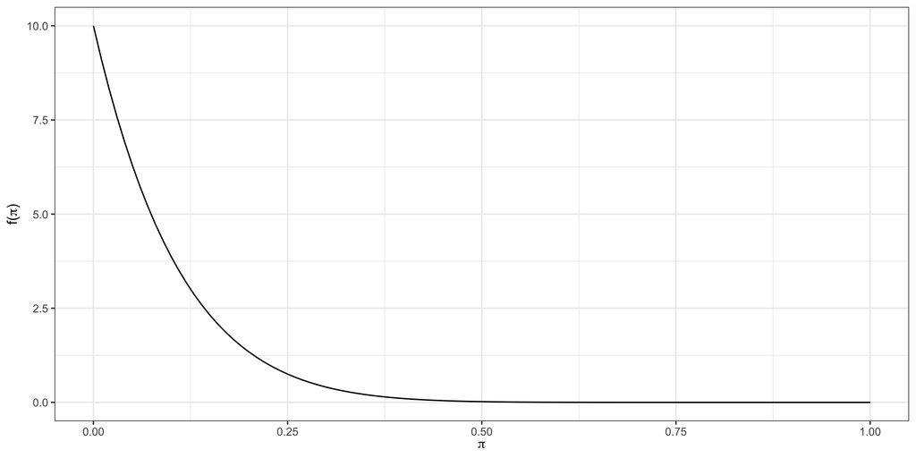

**c. They’re fairly certain that only a small proportion of people will do what authority tells them.**

## Example

- After data collection, $Y = 26$ of the $n=40$ study participants inflected what they understood to be the maximum shock.
- From the problem set up,

$$\begin{align*}
Y|\pi &\sim \text{Bin}(40, \pi) \\
\pi &\sim \text{Beta}(1, 10)
\end{align*}$$

- Use what you know to find the posterior model of $\pi$,

$$\pi|(Y=26) \sim \text{Beta}(\text{??}, \text{??})$$

## Example

- After data collection, $Y = 26$ of the $n=40$ study participants inflected what they understood to be the maximum shock.
- Use what you know to find the posterior model of $\pi$,

$$\pi|(Y=26) \sim \text{Beta}(\text{??}, \text{??})$$

- With $\alpha = 1$ and $\beta = 10$, we know the posterior distribution will be as follows,

$$\begin{align*}
\pi | (Y=y) &\sim \text{Beta}(\alpha+y, \beta+n-y) \\
&\sim \text{Beta}(1+26, 10+40-26) \\
&\sim \text{Beta}(27, 24)
\end{align*}$$

## Example

- Let’s find the summary,

```r
summarize_beta_binomial(alpha = 1, beta = 10, y = 26, n = 40)
```

- and graph the distributions involved,

```r
plot_beta_binomial(alpha = 1, beta = 10, y = 26, n = 40)
```

- What belief did we have for $\pi$ before considering the data?
- What belief do we have for $\pi$ after considering the prior and the observed data?

## Example

- Let’s find the summary,

```r
summarize_beta_binomial(alpha = 1, beta = 10, y = 26, n = 40)
```

| model | alpha | beta | mean | mode | var | sd |
| --- | --- | --- | --- | --- | --- | --- |
| prior | 1 | 10 | 0.09090909 | 0.0000000 | 0.006887052 | 0.08298827 |
| posterior | 27 | 24 | 0.52941176 | 0.5306122 | 0.004791057 | 0.06921746 |

## Example

- Let’s graph the distributions involved,

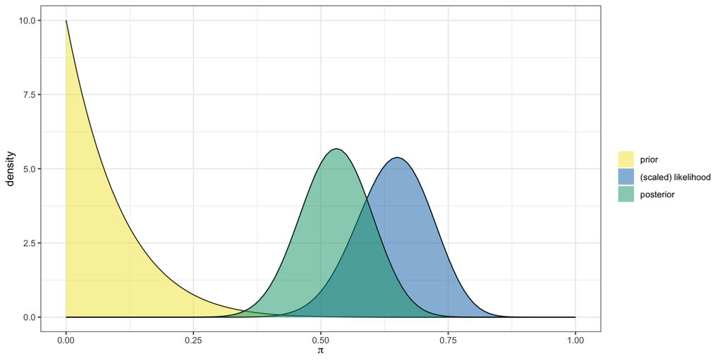

```r
plot_beta_binomial(alpha = 1, beta = 10, y = 26, n = 40) + theme_bw()
```

## Example

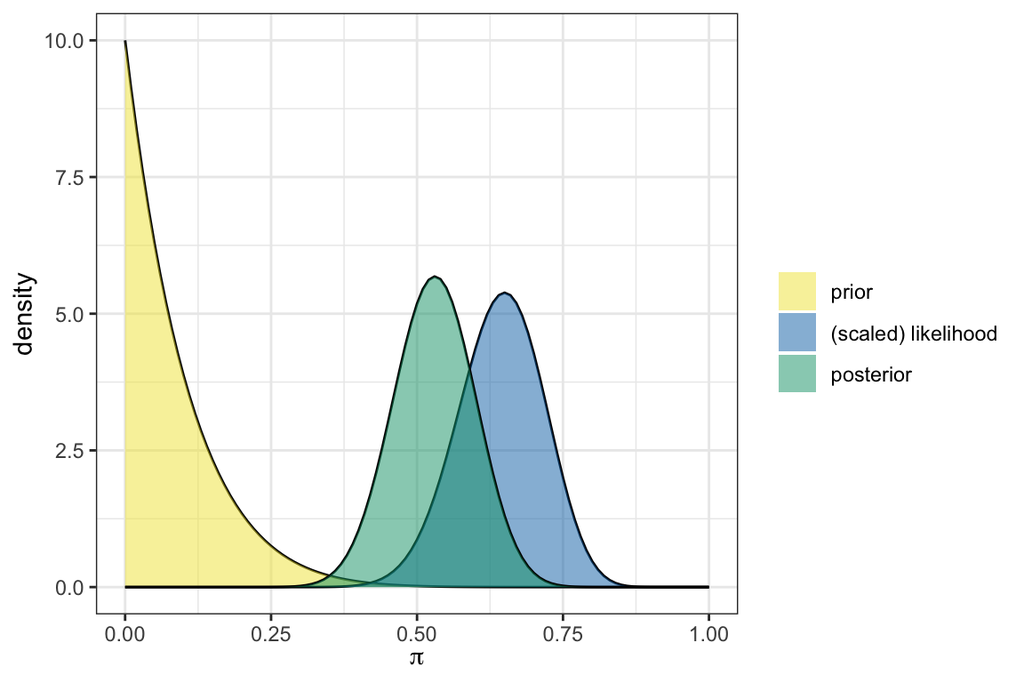

- What belief did we have for $\pi$ before considering the data?
  - Fewer than 25% of people would inflict the most severe shock.
- What belief do we have for $\pi$ after considering the prior and the observed data?
  - Somewhere between 30% and 70% of people would inflict the most severe shock.

## Wrap Up: Beta-Binomial

- We have built the Beta-Binomial model for $\pi$, an unknown proportion.

$$\begin{equation*}
\begin{aligned}
Y|\pi &\sim \text{Bin}(n,\pi) \\
\pi &\sim \text{Beta}(\alpha,\beta) &
\end{aligned}
\Rightarrow
\begin{aligned}
&& \pi | (Y=y) &\sim \text{Beta}(\alpha+y, \beta+n-y) \\
\end{aligned}
\end{equation*}$$

- The prior model, $f(\pi)$, is given by Beta($\alpha,\beta$).
- The data model, $f(Y|\pi)$, is given by Bin($n,\pi$).
- The likelihood function, $L(\pi|y)$, is obtained by plugging $y$ into the Binomial pmf.
- The posterior model is a Beta distribution with updated parameters $\alpha+y$ and $\beta+n-y$.

## Homework

- 1.3
- 1.4
- 1.8
- 2.4
- 2.9
- 3.3
- 3.9
- 3.10
- 3.18